# Google Data Analysis Capstone Project - Bellabeat Case Study

Mfon Stephen Nwa

9/10/2021

## Case Study 2: How can a wellness technology company play it smart?

[figure not shown]

## INTRODUCTION

This is the Bellabeat case study, a capstone project for the Google Data Analysis Certificate. In this Case Study I will analyse smart devices data for Bellabeat(a manufacturer of health focused products for women)in order to gain insights into how customers are using their smart devices and unlock new growth potential for the company.

### Deliverables

- A clear summary of the business task
- A description of all data sources used
- Documentation of any cleaning or manipulation of data
- A summary of the analysis
- Supporting visualizations and key ﬁndings
- Recommendations based on the analysis

### Business Task

Analyze FitBit fitness tracker data to gain insights into how consumers are using the FitBit app and discover trends for Bellabeat marketing strategy.

For this Analysis I shall be using the six step data analysis process:

- Ask
- Prepare
- Process
- Analyse
- Share
- Act

## ASK

In this step I shall identify questions we hope to solve with this analysis

I shall try to identify:

- Daily trends in user activity
- Hourly trends in user activity
- Relationships between variables

## PREPARE

In the prepare stage, I shall identify the data being used, its nature and format, examine its credibility, and its limitations.

### Data Source Description

I shall be using public dataset from [FitBit](https://www.kaggle.com/arashnic/fitbit) stored on Kaggle. This Kaggle data set is made up of 18 csv files that contains personal ﬁtness tracker from thirty ﬁtbit users.

Thirty eligible Fitbit users consented to the submission of personal tracker data, including minute-level output for physical activity, heart rate, and sleep monitoring. It includes information about daily activity, steps, and heart rate that can be used to explore users’ habits.

To examine the data’s credibility I shall be using the acronym ROCCC

- R - Reliable: The dataset is not Reliable as it contains data from only 30 people
- O - Original: The dataset is not original as it is third party data(via Amazon Mechanical Turk)
- C - Comprehensive: The dataset is comprehensive as most of the parameters match those of Bellabeats
- C - Current: The dataset is not current as it was gathered 5 years ago(2016)
- C - Cited: The dataset is well cited, it is cited as; Furberg, R. Brinton, J. Keating, M. & Ortiz, A. (2016). Crowd-sourced Fitbit datasets 03.12.2016-05.12.2016 [Data set]. Zenodo. https://doi.org/10.5281/zenodo.53894. Although it is third party it clearly states the source of the data.

The Dataset credibility is not sufficient enough to provide reliable insight for Bellabeats, Therefore insights generated will have to be verified with further analysis of a more reliable data set

## PROCESS

Here, I shall explore, clean and process the data for the analysis stage. I shall be using R for the data cleaning, transformation, analysis, and visualization.

I am going to be using the following packages for this project:

- tidyverse
- skimr
- chron

Then to load the data

```r
daily_activity_full <- read.csv("bellabeat data/dailyActivity_merged.csv")

daily_calories <- read.csv("bellabeat data/dailyCalories_merged.csv")

daily_steps <- read.csv("bellabeat data/dailySteps_merged.csv")

daily_intensity <- read.csv("bellabeat data/dailyIntensities_merged.csv")

sleep_minutes <- read.csv("bellabeat data/minuteSleep_merged.csv")

sleep_days <- read.csv("bellabeat data/sleepDay_merged.csv")

weight_log <- read.csv("bellabeat data/weightLogInfo_merged.csv")

hourly_steps <- read.csv("bellabeat data/hourlySteps_merged.csv")

hourly_intensity <- read.csv("bellabeat data/hourlyIntensities_merged.csv")

hourly_calories <- read.csv("bellabeat data/hourlyCalories_merged.csv")
```

```r
head(daily_activity_full)
```

```
##           Id ActivityDate TotalSteps TotalDistance TrackerDistance
## 1 1503960366    4/12/2016      13162          8.50            8.50
## 2 1503960366    4/13/2016      10735          6.97            6.97
## 3 1503960366    4/14/2016      10460          6.74            6.74
## 4 1503960366    4/15/2016       9762          6.28            6.28
## 5 1503960366    4/16/2016      12669          8.16            8.16
## 6 1503960366    4/17/2016       9705          6.48            6.48
##   LoggedActivitiesDistance VeryActiveDistance ModeratelyActiveDistance
## 1                        0               1.88                     0.55
## 2                        0               1.57                     0.69
## 3                        0               2.44                     0.40
## 4                        0               2.14                     1.26
## 5                        0               2.71                     0.41
## 6                        0               3.19                     0.78
##   LightActiveDistance SedentaryActiveDistance VeryActiveMinutes
## 1                6.06                       0                25
## 2                4.71                       0                21
## 3                3.91                       0                30
## 4                2.83                       0                29
## 5                5.04                       0                36
## 6                2.51                       0                38
##   FairlyActiveMinutes LightlyActiveMinutes SedentaryMinutes Calories
## 1                  13                  328              728     1985
## 2                  19                  217              776     1797
## 3                  11                  181             1218     1776
## 4                  34                  209              726     1745
## 5                  10                  221              773     1863
## 6                  20                  164              539     1728
```

```r
head(daily_calories)
```

```
##           Id ActivityDay Calories
## 1 1503960366   4/12/2016     1985
## 2 1503960366   4/13/2016     1797
## 3 1503960366   4/14/2016     1776
## 4 1503960366   4/15/2016     1745
## 5 1503960366   4/16/2016     1863
## 6 1503960366   4/17/2016     1728
```

```r
head(daily_steps)
```

```
##           Id ActivityDay StepTotal
## 1 1503960366   4/12/2016     13162
## 2 1503960366   4/13/2016     10735
## 3 1503960366   4/14/2016     10460
## 4 1503960366   4/15/2016      9762
## 5 1503960366   4/16/2016     12669
## 6 1503960366   4/17/2016      9705
```

```r
head(daily_intensity)
```

```
##           Id ActivityDay SedentaryMinutes LightlyActiveMinutes
## 1 1503960366   4/12/2016              728                  328
## 2 1503960366   4/13/2016              776                  217
## 3 1503960366   4/14/2016             1218                  181
## 4 1503960366   4/15/2016              726                  209
## 5 1503960366   4/16/2016              773                  221
## 6 1503960366   4/17/2016              539                  164
##   FairlyActiveMinutes VeryActiveMinutes SedentaryActiveDistance
## 1                  13                25                       0
## 2                  19                21                       0
## 3                  11                30                       0
## 4                  34                29                       0
## 5                  10                36                       0
## 6                  20                38                       0
##   LightActiveDistance ModeratelyActiveDistance VeryActiveDistance
## 1                6.06                     0.55               1.88
## 2                4.71                     0.69               1.57
## 3                3.91                     0.40               2.44
## 4                2.83                     1.26               2.14
## 5                5.04                     0.41               2.71
## 6                2.51                     0.78               3.19
```

```r
head(sleep_minutes)
```

```
##           Id                 date value       logId
## 1 1503960366 4/12/2016 2:47:30 AM     3 11380564589
## 2 1503960366 4/12/2016 2:48:30 AM     2 11380564589
## 3 1503960366 4/12/2016 2:49:30 AM     1 11380564589
## 4 1503960366 4/12/2016 2:50:30 AM     1 11380564589
## 5 1503960366 4/12/2016 2:51:30 AM     1 11380564589
## 6 1503960366 4/12/2016 2:52:30 AM     1 11380564589
```

```r
head(sleep_days)
```

```
##           Id              SleepDay TotalSleepRecords TotalMinutesAsleep
## 1 1503960366 4/12/2016 12:00:00 AM                 1                327
## 2 1503960366 4/13/2016 12:00:00 AM                 2                384
## 3 1503960366 4/15/2016 12:00:00 AM                 1                412
## 4 1503960366 4/16/2016 12:00:00 AM                 2                340
## 5 1503960366 4/17/2016 12:00:00 AM                 1                700
## 6 1503960366 4/19/2016 12:00:00 AM                 1                304
##   TotalTimeInBed
## 1            346
## 2            407
## 3            442
## 4            367
## 5            712
## 6            320
```

```r
head(weight_log)
```

```
##           Id                  Date WeightKg WeightPounds Fat   BMI
## 1 1503960366  5/2/2016 11:59:59 PM     52.6     115.9631  22 22.65
## 2 1503960366  5/3/2016 11:59:59 PM     52.6     115.9631  NA 22.65
## 3 1927972279  4/13/2016 1:08:52 AM    133.5     294.3171  NA 47.54
## 4 2873212765 4/21/2016 11:59:59 PM     56.7     125.0021  NA 21.45
## 5 2873212765 5/12/2016 11:59:59 PM     57.3     126.3249  NA 21.69
## 6 4319703577 4/17/2016 11:59:59 PM     72.4     159.6147  25 27.45
##   IsManualReport        LogId
## 1           True 1.462234e+12
## 2           True 1.462320e+12
## 3          False 1.460510e+12
## 4           True 1.461283e+12
## 5           True 1.463098e+12
## 6           True 1.460938e+12
```

```r
head(hourly_steps)
```

```
##           Id          ActivityHour StepTotal
## 1 1503960366 4/12/2016 12:00:00 AM       373
## 2 1503960366  4/12/2016 1:00:00 AM       160
## 3 1503960366  4/12/2016 2:00:00 AM       151
## 4 1503960366  4/12/2016 3:00:00 AM         0
## 5 1503960366  4/12/2016 4:00:00 AM         0
## 6 1503960366  4/12/2016 5:00:00 AM         0
```

```r
head(hourly_intensity)
```

```
##           Id          ActivityHour TotalIntensity AverageIntensity
## 1 1503960366 4/12/2016 12:00:00 AM             20         0.333333
## 2 1503960366  4/12/2016 1:00:00 AM              8         0.133333
## 3 1503960366  4/12/2016 2:00:00 AM              7         0.116667
## 4 1503960366  4/12/2016 3:00:00 AM              0         0.000000
## 5 1503960366  4/12/2016 4:00:00 AM              0         0.000000
## 6 1503960366  4/12/2016 5:00:00 AM              0         0.000000
```

```r
head(hourly_calories)
```

```
##           Id          ActivityHour Calories
## 1 1503960366 4/12/2016 12:00:00 AM       81
## 2 1503960366  4/12/2016 1:00:00 AM       61
## 3 1503960366  4/12/2016 2:00:00 AM       59
## 4 1503960366  4/12/2016 3:00:00 AM       47
## 5 1503960366  4/12/2016 4:00:00 AM       48
## 6 1503960366  4/12/2016 5:00:00 AM       48
```

From viewing the data I can notice that there are some data that are similar

The data is divided into the following categories:

- Weight
- Intensity
  - hourly
  - daily
- Calories
  - hourly
  - daily
- Steps
  - hourly
  - daily
- Sleep
  - minutes
  - daily

The daily_calories, daily_intensity and daily_steps data frames all have the same number of rows as the daily_activity_full data frame. To confirm that they all contain the same information, I will extract the common columns and check if they are identical

```r
all(select(daily_activity_full,Id,ActivityDate,Calories) == daily_calories)
```

```
## [1] TRUE
```

It shows that exactly the same information is in both data frames

Checking with the ‘daily_intensity’ data frame

```r
all(select(daily_activity_full,Id,ActivityDate,SedentaryMinutes,LightlyActiveMinutes,FairlyActiveMinutes,VeryActiveMinutes,SedentaryActiveDistance,LightActiveDistance,ModeratelyActiveDistance,VeryActiveDistance) == daily_intensity)
```

```
## [1] TRUE
```

The ‘daily_intensity’ data is contained in the ‘daily_activity_full’ data.

Finally to confirm that the ‘daily_steps’ data frame is also contained in the ‘daily_activity_full’ data frame

```r
all(select(daily_activity_full,Id,ActivityDate,TotalSteps) == daily_steps)
```

```
## [1] TRUE
```

The ‘daily_steps’ data frame is contained in the ‘daily_activity_full’ data frame.

Since these 3 data frames are all present in the ‘daily_activity_full’ data frame I can safely remove these data frames from the analysis for simplicity.

The ‘hourly_calories’, ‘hourly_intensity’, and ‘hourly_steps’ all have the same number of rows so I will verify if they contain the same data

```r
all(
  select(hourly_steps,Id,ActivityHour) == select(hourly_intensity,Id,ActivityHour)
)
```

```
## [1] TRUE
```

```r
all(
  select(hourly_steps,Id,ActivityHour) == select(hourly_calories,Id,ActivityHour)
)
```

```
## [1] TRUE
```

So I can safely join the data frames

```r
hourly_activity <- hourly_calories %>%
  inner_join(hourly_intensity) %>%
  inner_join(hourly_steps)
```

The ‘sleep_days’ contains the sleep data frame on a day-to-day basis while the ‘sleep_minutes’ data frame contains the same data just on a minute-to-minute basis To confirm if they contain the same participants

```r
all(distinct(sleep_days,Id) == distinct(sleep_minutes,Id))
```

```
## [1] TRUE
```

I shall be using the ‘sleep_day’ data frame for this analysis So I am left with the following Four Data Frames:

- daily_activity_full
- hourly_activity
- sleep_day
- weight_log

### Data Cleaning and Manipulation

```r
# To check for missing values

sum(is.na(daily_activity_full))
```

```
## [1] 0
```

```r
sum(is.na(hourly_activity))
```

```
## [1] 0
```

```r
sum(is.na(sleep_days))
```

```
## [1] 0
```

```r
sum(is.na(weight_log))
```

```
## [1] 65
```

There are no null or missing values except in the “weight_log” data frame.To better understand the missing data

```r
is.na(weight_log)
```

```
##          Id  Date WeightKg WeightPounds   Fat   BMI IsManualReport LogId
##  [1,] FALSE FALSE    FALSE        FALSE FALSE FALSE          FALSE FALSE
##  [2,] FALSE FALSE    FALSE        FALSE  TRUE FALSE          FALSE FALSE
##  [3,] FALSE FALSE    FALSE        FALSE  TRUE FALSE          FALSE FALSE
##  [4,] FALSE FALSE    FALSE        FALSE  TRUE FALSE          FALSE FALSE
##  [5,] FALSE FALSE    FALSE        FALSE  TRUE FALSE          FALSE FALSE
##  [6,] FALSE FALSE    FALSE        FALSE FALSE FALSE          FALSE FALSE
##  [7,] FALSE FALSE    FALSE        FALSE  TRUE FALSE          FALSE FALSE
##  [8,] FALSE FALSE    FALSE        FALSE  TRUE FALSE          FALSE FALSE
##  [9,] FALSE FALSE    FALSE        FALSE  TRUE FALSE          FALSE FALSE
## [10,] FALSE FALSE    FALSE        FALSE  TRUE FALSE          FALSE FALSE
## [11,] FALSE FALSE    FALSE        FALSE  TRUE FALSE          FALSE FALSE
## [12,] FALSE FALSE    FALSE        FALSE  TRUE FALSE          FALSE FALSE
## [13,] FALSE FALSE    FALSE        FALSE  TRUE FALSE          FALSE FALSE
## [14,] FALSE FALSE    FALSE        FALSE  TRUE FALSE          FALSE FALSE
```

[output cut: 53 more lines]

From the table I can see that the data has a lot of missing values, Majority of which are in the “Fat” column. So for futher analysis I will remove the “Fat” column as it isn’t usefull and may contain errors

```r
weight_log <- weight_log %>% select(-Fat)
```

To check for mis-matched data types

```r
glimpse(daily_activity_full)
```

```
## Rows: 940
## Columns: 15
## $ Id                       <dbl> 1503960366, 1503960366, 1503960366, 150396036~
## $ ActivityDate             <chr> "4/12/2016", "4/13/2016", "4/14/2016", "4/15/~
## $ TotalSteps               <int> 13162, 10735, 10460, 9762, 12669, 9705, 13019~
## $ TotalDistance            <dbl> 8.50, 6.97, 6.74, 6.28, 8.16, 6.48, 8.59, 9.8~
## $ TrackerDistance          <dbl> 8.50, 6.97, 6.74, 6.28, 8.16, 6.48, 8.59, 9.8~
## $ LoggedActivitiesDistance <dbl> 0, 0, 0, 0, 0, 0, 0, 0, 0, 0, 0, 0, 0, 0, 0, ~
## $ VeryActiveDistance       <dbl> 1.88, 1.57, 2.44, 2.14, 2.71, 3.19, 3.25, 3.5~
## $ ModeratelyActiveDistance <dbl> 0.55, 0.69, 0.40, 1.26, 0.41, 0.78, 0.64, 1.3~
## $ LightActiveDistance      <dbl> 6.06, 4.71, 3.91, 2.83, 5.04, 2.51, 4.71, 5.0~
## $ SedentaryActiveDistance  <dbl> 0, 0, 0, 0, 0, 0, 0, 0, 0, 0, 0, 0, 0, 0, 0, ~
## $ VeryActiveMinutes        <int> 25, 21, 30, 29, 36, 38, 42, 50, 28, 19, 66, 4~
## $ FairlyActiveMinutes      <int> 13, 19, 11, 34, 10, 20, 16, 31, 12, 8, 27, 21~
## $ LightlyActiveMinutes     <int> 328, 217, 181, 209, 221, 164, 233, 264, 205, ~
## $ SedentaryMinutes         <int> 728, 776, 1218, 726, 773, 539, 1149, 775, 818~
## $ Calories                 <int> 1985, 1797, 1776, 1745, 1863, 1728, 1921, 203~
```

```r
glimpse(hourly_activity)
```

```
## Rows: 22,099
## Columns: 6
## $ Id               <dbl> 1503960366, 1503960366, 1503960366, 1503960366, 15039~
## $ ActivityHour     <chr> "4/12/2016 12:00:00 AM", "4/12/2016 1:00:00 AM", "4/1~
## $ Calories         <int> 81, 61, 59, 47, 48, 48, 48, 47, 68, 141, 99, 76, 73, ~
## $ TotalIntensity   <int> 20, 8, 7, 0, 0, 0, 0, 0, 13, 30, 29, 12, 11, 6, 36, 5~
## $ AverageIntensity <dbl> 0.333333, 0.133333, 0.116667, 0.000000, 0.000000, 0.0~
## $ StepTotal        <int> 373, 160, 151, 0, 0, 0, 0, 0, 250, 1864, 676, 360, 25~
```

```r
glimpse(sleep_days)
```

```
## Rows: 413
## Columns: 5
## $ Id                 <dbl> 1503960366, 1503960366, 1503960366, 1503960366, 150~
## $ SleepDay           <chr> "4/12/2016 12:00:00 AM", "4/13/2016 12:00:00 AM", "~
## $ TotalSleepRecords  <int> 1, 2, 1, 2, 1, 1, 1, 1, 1, 1, 1, 1, 1, 1, 1, 1, 1, ~
## $ TotalMinutesAsleep <int> 327, 384, 412, 340, 700, 304, 360, 325, 361, 430, 2~
## $ TotalTimeInBed     <int> 346, 407, 442, 367, 712, 320, 377, 364, 384, 449, 3~
```

```r
glimpse(weight_log)
```

```
## Rows: 67
## Columns: 7
## $ Id             <dbl> 1503960366, 1503960366, 1927972279, 2873212765, 2873212~
## $ Date           <chr> "5/2/2016 11:59:59 PM", "5/3/2016 11:59:59 PM", "4/13/2~
## $ WeightKg       <dbl> 52.6, 52.6, 133.5, 56.7, 57.3, 72.4, 72.3, 69.7, 70.3, ~
## $ WeightPounds   <dbl> 115.9631, 115.9631, 294.3171, 125.0021, 126.3249, 159.6~
## $ BMI            <dbl> 22.65, 22.65, 47.54, 21.45, 21.69, 27.45, 27.38, 27.25,~
## $ IsManualReport <chr> "True", "True", "False", "True", "True", "True", "True"~
## $ LogId          <dbl> 1.462234e+12, 1.462320e+12, 1.460510e+12, 1.461283e+12,~
```

The Date and time are in the character format instead of the date or date-time format So to change that

```r
# To change the ActivityDate column in activity_date_full to date format

daily_activity_full$ActivityDate <-     as.Date(daily_activity_full$ActivityDate,format = "%m/%d/%Y")


# To change the ActivityHour column in hourly_activity to date-time format
# First i will separate the ActivityHour into date,time and period_of_day

hourly_activity <- hourly_activity %>% separate(ActivityHour,c("Date","Time","Period_of_day"),sep = " ")


# To convert the date and time to DateTime format

hourly_activity <- hourly_activity %>% mutate(Date_Time = (chron(dates = Date,times = Time,format = c('m/d/Y','h:m:s'))))

# To place the newly created DateTime beside the period of the day

hourly_activity <- hourly_activity[,c(1:3,9,4:8)]

# Now repeating the same for the remaining 2 data frames
# For the sleep_days data

sleep_days <- sleep_days %>% separate(SleepDay,c("Date","Time","Period_of_day"),sep = " ")

sleep_days$Date = as.Date(sleep_days$Date,format = "%m/%d/%Y")


# For the weight_log data

weight_log <- weight_log %>% separate(Date, c("Date","Time","Period_of_day"),sep = " ")

weight_log <- weight_log %>% mutate(Date_Time = (chron(dates = Date,times = Time,format = c('m/d/y','h:m:s'))))

weight_log <- weight_log[,c(1:3,10,4:9)]
```

To check for duplicates in the data

```r
sum(duplicated(daily_activity_full) == TRUE)
```

```
## [1] 0
```

```r
sum(duplicated(hourly_activity) == TRUE)
```

```
## [1] 0
```

```r
sum(duplicated(sleep_days) == TRUE)
```

```
## [1] 3
```

```r
sum(duplicated(weight_log) == TRUE)
```

```
## [1] 0
```

To remove duplicate data in “sleep_days”

```r
sleep_days <- sleep_days %>% distinct()
```

The misspelled or mistyped values(if any) are much more difficult to identify as the majority of the data is numerical. So for this dataframe I will assume there is no misspelled or mistyped values

To check for errors and confirm the business logic of the data, First i will check for the duration of entries in the dataframes

```r
range(daily_activity_full$ActivityDate)
```

```
## [1] "2016-04-12" "2016-05-12"
```

```r
range(hourly_activity$Date_Time)
```

```
## [1] (04/12/16 01:00:00) (05/12/16 12:00:00)
```

```r
range(weight_log$Date_Time)
```

```
## [1] (04/12/16 06:47:11) (05/12/16 11:59:59)
```

```r
range(sleep_days$Date)
```

```
## [1] "2016-04-12" "2016-05-12"
```

All the data sets have the same range of a month with is the same as in the description

Then I will check for the number of different participants in each of the data sets

```r
n_distinct(daily_activity_full$Id)
```

```
## [1] 33
```

```r
n_distinct(hourly_activity$Id)
```

```
## [1] 33
```

```r
n_distinct(sleep_days$Id)
```

```
## [1] 24
```

```r
n_distinct(weight_log$Id)
```

```
## [1] 8
```

The weight_log data both has too small a number of participants to generate reliable and valuable insights. Also the number of participants is not exactly 30, This might be an error in the data collection process or the data is incomplete.

### Data Cleaning and Manipulation Documentation

Data Cleaning

Data Manipulation

- Removed duplicates
- Converted dates to the appropriate data type

## ANALYSE

In the analyse stage I will examine and organize the data to try and discover insights and relationships.

To get the mean hourly steps and calories for each hour of the day

```r
Hourly_Steps <- hourly_activity %>% group_by(Hour = hours(Date_Time),Period_of_day) %>% summarise(Mean_Steps = mean(StepTotal)) %>%  arrange(Period_of_day)
Hourly_Steps <- Hourly_Steps[c(1:11,24,13:23,12),]

Hourly_Steps <- Hourly_Steps %>%  unite("Time_Of_Day",Hour,Period_of_day,sep = " ")

Hourly_Steps %>% arrange(desc(Mean_Steps))
```

```
## # A tibble: 24 x 2
##    Time_Of_Day Mean_Steps
##    <chr>            <dbl>
##  1 6 PM              599.
##  2 7 PM              583.
##  3 5 PM              550.
##  4 12 PM             549.
##  5 2 PM              541.
##  6 1 PM              538.
##  7 4 PM              497.
##  8 10 AM             482.
##  9 11 AM             457.
## 10 9 AM              433.
## # ... with 14 more rows
```

The table shows the times of the day and the corresponding steps taken from the most to the least it shows that 6pm is the hour the participants generally take the most steps and 3am is the hour with the least steps taken

```r
Hourly_Calories <- hourly_activity %>% group_by(Hour = hours(Date_Time),Period_of_day) %>% summarise(Mean_Calories = mean(Calories)) %>%  arrange(Period_of_day)
Hourly_Calories <- Hourly_Calories[c(1:11,24,13:23,12),]

Hourly_Calories <- Hourly_Calories %>%  unite("Time_Of_Day",Hour,Period_of_day,sep = " ")

Hourly_Calories %>% arrange(desc(Mean_Calories))
```

```
## # A tibble: 24 x 2
##    Time_Of_Day Mean_Calories
##    <chr>               <dbl>
##  1 6 PM                 123.
##  2 5 PM                 123.
##  3 7 PM                 121.
##  4 12 PM                117.
##  5 2 PM                 116.
##  6 1 PM                 115.
##  7 4 PM                 113.
##  8 10 AM                110.
##  9 11 AM                110.
## 10 3 PM                 107.
## # ... with 14 more rows
```

The table show the times and the corresponding mean calories burnt by the participants.

It show also that 6pm is the time that the participants generally burn the most calories and also that 3am is the time with the least calories burnt

Both tables appear to be quite similar which indicates that there is a correlation between steps taken and calories burnt

```r
Day_Step_Distance <- daily_activity_full %>% group_by(Days = weekdays(ActivityDate)) %>% summarise(Mean_Steps = mean(TotalSteps),MeanDistance_km = mean(TotalDistance))

Day_Step_Distance <- Day_Step_Distance[c(2,6,7,5,1,3,4),]

Day_Step_Distance %>% arrange(desc(Mean_Steps))
```

```
## # A tibble: 7 x 3
##   Days      Mean_Steps MeanDistance_km
##   <chr>          <dbl>           <dbl>
## 1 Saturday       8153.            5.85
## 2 Tuesday        8125.            5.83
## 3 Monday         7781.            5.55
## 4 Wednesday      7559.            5.49
## 5 Friday         7448.            5.31
## 6 Thursday       7406.            5.31
## 7 Sunday         6933.            5.03
```

The table shows that Saturday on average is the day with the most steps taken and total distance covered while Sunday is the day with the least steps taken and distance covered. there is a strong correlation between the steps taken and the total distance covered.

According to an article from the Center for Disease and prevention(CDC) published on [MedicalNewsToday](https://www.medicalnewstoday.com/articles/how-many-steps-should-you-take-a-day) by Jennifer Huizen on 26 February 2021, which states that most adults should aim for around 10,000 steps daily(about 8 kilometers,or 5 miles) as walking has several health benefits and can even prevent certain health conditions.

```r
Day_Calories <- daily_activity_full %>% group_by(Day = weekdays(ActivityDate)) %>% summarise(Mean_calories = mean(Calories))

Day_Calories <- Day_Calories[c(2,6,7,5,1,3,4),]

Day_Calories %>% arrange(desc(Mean_calories))
```

```
## # A tibble: 7 x 2
##   Day       Mean_calories
##   <chr>             <dbl>
## 1 Tuesday           2356.
## 2 Saturday          2355.
## 3 Friday            2332.
## 4 Monday            2324.
## 5 Wednesday         2303.
## 6 Sunday            2263
## 7 Thursday          2200.
```

The table shows the mean calories burnt each day It shows that Tuesday is the day with the most calories burnt and Thursday with the least calories.

There is a slight correlation with the daily calories burnt and daily steps.However the correlation isn’t as strong a the correlation with the hourly steps taken and hourly calories burnt, also the difference in calories across the days is relatively insignificant( >150 Calories) therefore the average calories burnt is fairly stable

```r
Daily_Active_Distances <- daily_activity_full %>% group_by(Day = weekdays(ActivityDate)) %>% summarise(MeanActiceDistance_km = mean(VeryActiveDistance))

Daily_Active_Distances <- Daily_Active_Distances[c(2,6,7,5,1,3,4),]

Daily_Active_Distances %>% arrange(desc(MeanActiceDistance_km))
```

```
## # A tibble: 7 x 2
##   Day       MeanActiceDistance_km
##   <chr>                     <dbl>
## 1 Wednesday                  1.63
## 2 Tuesday                    1.61
## 3 Monday                     1.54
## 4 Saturday                   1.51
## 5 Sunday                     1.49
## 6 Thursday                   1.39
## 7 Friday                     1.31
```

The table shows the mean active distance covered each day It shows that on average Wednesday is the day the participants covered the most active distances and Friday the day with the least mean active distances

```r
daily_activity_full %>% select(Id,VeryActiveMinutes,FairlyActiveMinutes,LightlyActiveMinutes,SedentaryMinutes) %>% summary()
```

```
##        Id            VeryActiveMinutes FairlyActiveMinutes LightlyActiveMinutes
##  Min.   :1.504e+09   Min.   :  0.00    Min.   :  0.00      Min.   :  0.0
##  1st Qu.:2.320e+09   1st Qu.:  0.00    1st Qu.:  0.00      1st Qu.:127.0
##  Median :4.445e+09   Median :  4.00    Median :  6.00      Median :199.0
##  Mean   :4.855e+09   Mean   : 21.16    Mean   : 13.56      Mean   :192.8
##  3rd Qu.:6.962e+09   3rd Qu.: 32.00    3rd Qu.: 19.00      3rd Qu.:264.0
##  Max.   :8.878e+09   Max.   :210.00    Max.   :143.00      Max.   :518.0
##  SedentaryMinutes
##  Min.   :   0.0
##  1st Qu.: 729.8
##  Median :1057.5
##  Mean   : 991.2
##  3rd Qu.:1229.5
##  Max.   :1440.0
```

For the analysis of the sleep data frame To get the mean time in bed for each day of the week

```r
sleep_days %>% select(TotalMinutesAsleep,TotalTimeInBed) %>% summary()
```

```
##  TotalMinutesAsleep TotalTimeInBed
##  Min.   : 58.0      Min.   : 61.0
##  1st Qu.:361.0      1st Qu.:403.8
##  Median :432.5      Median :463.0
##  Mean   :419.2      Mean   :458.5
##  3rd Qu.:490.0      3rd Qu.:526.0
##  Max.   :796.0      Max.   :961.0
```

```r
Daily_Sleep_Data <- sleep_days %>% group_by(Day = weekdays(Date)) %>% summarise(Mean_Time_in_bed = mean(TotalTimeInBed),Mean_Time_Asleep = mean(TotalMinutesAsleep))

Daily_Sleep_Data <- Daily_Sleep_Data[c(2,6,7,5,1,3,4),]

Daily_Sleep_Data %>% arrange(desc(Mean_Time_in_bed))
```

```
## # A tibble: 7 x 3
##   Day       Mean_Time_in_bed Mean_Time_Asleep
##   <chr>                <dbl>            <dbl>
## 1 Sunday                504.             453.
## 2 Wednesday             470.             435.
## 3 Saturday              460.             419.
## 4 Monday                457.             420.
## 5 Friday                445.             405.
## 6 Tuesday               443.             405.
## 7 Thursday              435.             401.
```

The data table shows the mean total time in bed for each day it shows that Sunday is the day the participants generally spend the most times in bed and Thursday is the day that the participants spend the least time in bed

To explore the relationships between time in bed and sedentary minutes

```r
sleep_days <- sleep_days %>% rename(ActivityDate = Date)

Daily_Sleep_and_Activity_merged <- merge(sleep_days,daily_activity_full,by = c("Id","ActivityDate")) %>% mutate(TotalTimeInBed_HRS = TotalTimeInBed/60,TotalHoursAsleep = TotalMinutesAsleep/60)
```

Making a few exploratory plots to explore relationships between variables

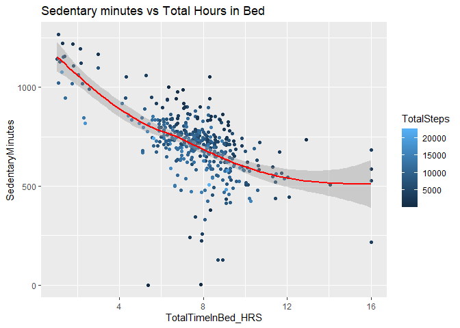

```r
# To explore the relationship between total time in bed, sedentary minutes and total steps

Daily_Sleep_and_Activity_merged %>% ggplot()+geom_point(aes(x=TotalTimeInBed_HRS,y=SedentaryMinutes,color =TotalSteps))+geom_smooth(aes(x=TotalTimeInBed_HRS,y=SedentaryMinutes),color="red") + labs(title = "Sedentary minutes vs Total Hours in Bed")
```

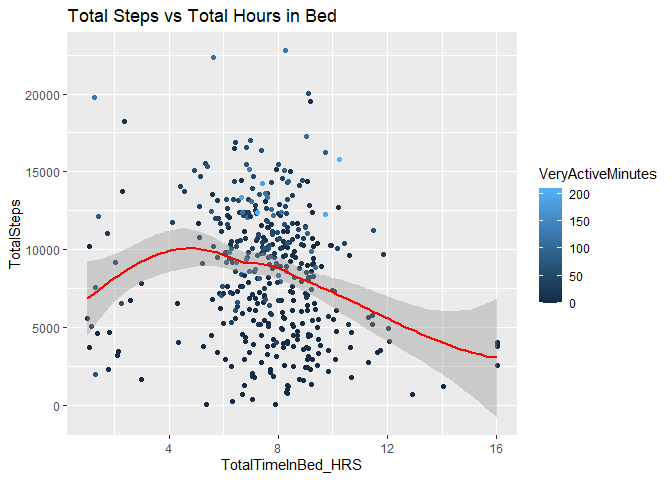

```r
# To explore the relationship between total time in bed, total steps and very active minutes.

Daily_Sleep_and_Activity_merged %>% ggplot()+geom_point(aes(x=TotalTimeInBed_HRS,y=TotalSteps,color =VeryActiveMinutes))+geom_smooth(aes(x=TotalTimeInBed_HRS,y=TotalSteps),color = "red") +labs(title = "Total Steps vs Total Hours in Bed")
```

The plot trend is similar to a bell curve, Majority of the users that took 10,000 steps or more spent between 6 - 10 hours in bed and they were active for more minutes.

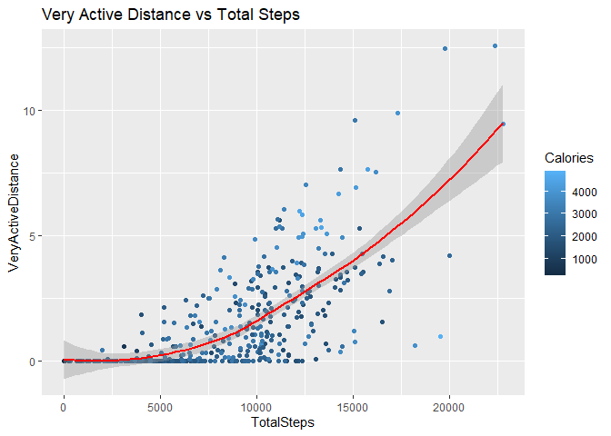

```r
# To explore the relationship between total steps in bed, very actice distances and calories

Daily_Sleep_and_Activity_merged %>% ggplot()+geom_point(aes(x=TotalSteps,y=VeryActiveDistance,color =Calories))+geom_smooth(aes(x=TotalSteps,y=VeryActiveDistance),color="red") + labs(title = "Very Active Distance vs Total Steps")
```

As expected the plot shows a positive correlation with very active distances and Total steps.

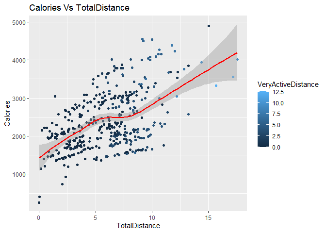

```r
# To explore the relationship between total distance and calories

Daily_Sleep_and_Activity_merged %>% ggplot()+geom_point(aes(x=TotalDistance,y=Calories,color =VeryActiveDistance))+geom_smooth(aes(x=TotalDistance,y=Calories),color="red") + labs(title = "Calories Vs TotalDistance")
```

The plot shows a positive correlation with calories, total distance and very active distances.

For the analysis of the weight data frame To get the frequency of the entry modes of the reports

```r
table1 = as.table(table(weight_log$IsManualReport))
prop.table(table1)
```

```
##
##     False      True
## 0.3880597 0.6119403
```

It show that 61% of the values was entered manually and 38.8% of the data values was generated automatically

```r
weight_log %>% group_by(Id) %>% summarise(Average_BMI = mean(BMI))
```

```
## # A tibble: 8 x 2
##           Id Average_BMI
##        <dbl>       <dbl>
## 1 1503960366        22.6
## 2 1927972279        47.5
## 3 2873212765        21.6
## 4 4319703577        27.4
## 5 4558609924        27.2
## 6 5577150313        28
## 7 6962181067        24.0
## 8 8877689391        25.5
```

The table shows the mean BMI(Body Mass Index) for each of the participants.

According to an article published on the [Center for Disease Control and Prevention Website](https://www.cdc.gov/obesity/adult/defining.html)(CDC) BMI below 18.5 falls under the underweight category,BMI between 18.5 and 25 falls under the healthy weight category, BMI between 25 and 30 falls within the overweight category, and BMI above 30 falls within the obesity category

It shows that no participant is underweight and 3 are healthy, 4 are overweight, and 1 is obese. However since the number of participants in the weight log data is so small, reliable conclusions cannot be drawn from the data.

## SHARE

In the Share stage I will be creating visualizations that communicate the findings made in the analysis.

### VISUALIZATIONS AND KEY FINDINGS

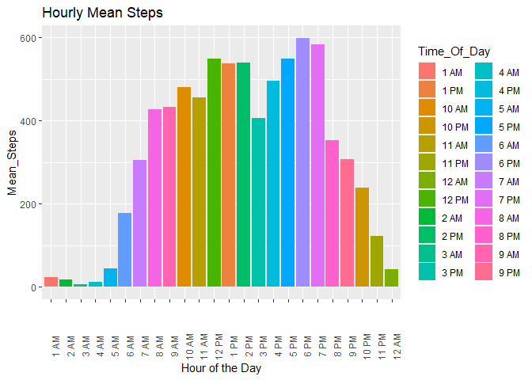

```r
ggplot(data = Hourly_Steps) + geom_col(mapping = aes(x = fct_inorder(Time_Of_Day),y = Mean_Steps,fill = Time_Of_Day)) + theme(axis.text.x=element_text(angle=90,margin = margin(1, unit = "cm"),vjust =1)) + labs(title="Hourly Mean Steps",x="Hour of the Day")
```

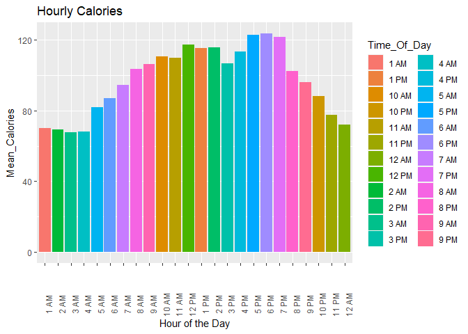

```r
ggplot(data = Hourly_Calories) + geom_col(mapping=aes(x=fct_inorder(Time_Of_Day),y=Mean_Calories,fill = Time_Of_Day)) + theme(axis.text.x=element_text(angle=90,margin = margin(1, unit = "cm"),vjust =1)) + labs(title="Hourly Calories",x="Hour of the Day")
```

Users are most active 6pm and most inactive 3am

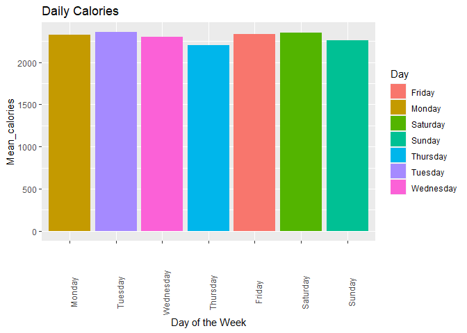

```r
ggplot(data = Day_Calories)+ geom_col(aes( x= fct_inorder(Day),y = Mean_calories,fill = Day)) + theme(axis.text.x=element_text(angle=90,margin = margin(1, unit = "cm"),vjust =1)) + labs(title="Daily Calories",x="Day of the Week")
```

There isn’t a significant difference in the daily calories burnt

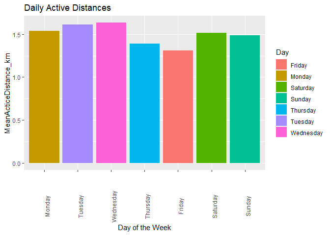

```r
ggplot(data = Daily_Active_Distances) + geom_col(aes(x=fct_inorder(Day),y=MeanActiceDistance_km,fill=Day)) + theme(axis.text.x=element_text(angle=90,margin = margin(1, unit = "cm"),vjust =1)) +labs(title="Daily Active Distances",x="Day of the Week")
```

On average users active for the longest distances during wednesdays.

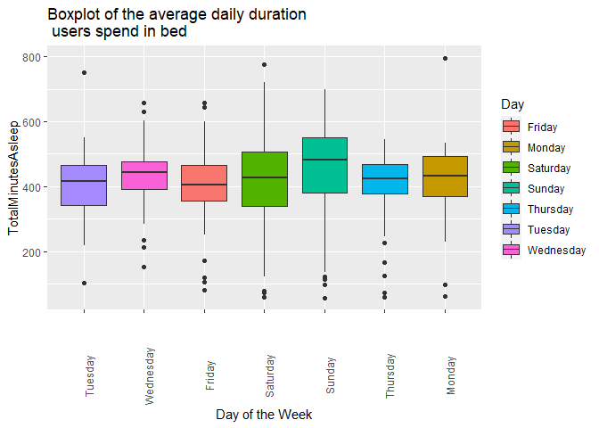

```r
ggplot(sleep_days %>% group_by(Day = weekdays(ActivityDate)))+geom_boxplot(aes(x=fct_inorder(Day),y=TotalMinutesAsleep,fill=Day,group = Day)) + labs(title = "Boxplot of the average daily duration \n users spend in bed",x="Day of the Week") + theme(axis.text.x=element_text(angle=90,margin = margin(1, unit = "cm"),vjust =1))
```

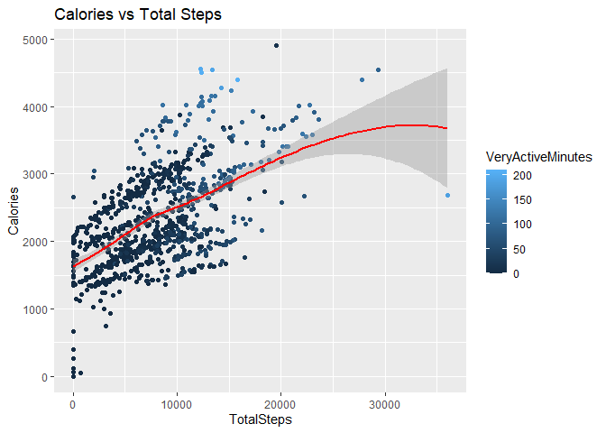

```r
ggplot(daily_activity_full)+geom_point(aes(x=TotalSteps,y=Calories,color=VeryActiveMinutes))+geom_smooth((aes(x=TotalSteps,y=Calories,color=VeryActiveMinutes)),color="red") + labs(title = "Calories vs Total Steps")
```

As expected the calories burnt increases as the daily total steps increases.

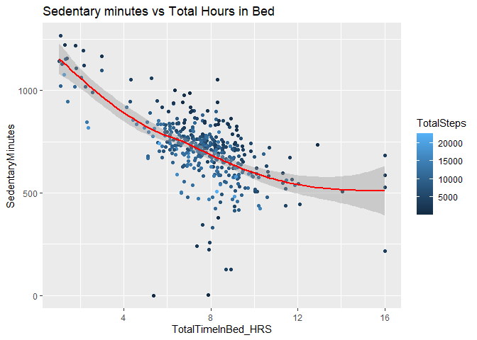

```r
Daily_Sleep_and_Activity_merged %>% ggplot()+geom_point(aes(x=TotalTimeInBed_HRS,y=SedentaryMinutes,color =TotalSteps))+geom_smooth(aes(x=TotalTimeInBed_HRS,y=SedentaryMinutes),color="red") + labs(title = "Sedentary minutes vs Total Hours in Bed")
```

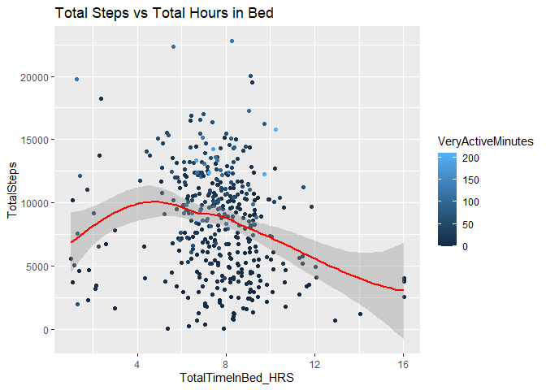

```r
Daily_Sleep_and_Activity_merged %>% ggplot()+geom_point(aes(x=TotalTimeInBed_HRS,y=TotalSteps,color =VeryActiveMinutes))+geom_smooth(aes(x=TotalTimeInBed_HRS,y=TotalSteps),color = "red") +labs(title = "Total Steps vs Total Hours in Bed")
```

## ACT

In the final step, I will be delivering my insights and providing recommendations based on my analysis. I shall be focusing on providing recommendations for the Bellabeats app

### RECOMMENDATIONS BASED ON ANALYSIS

- Enable notification to alert users when they have spent 10 hrs or more in bed
- Enable congratulation message to encourage users when they have reached the recommended 10,000 daily step
- Partner with health and fitness companies and offer discounts for users that spend most of the days being sedentary
- Enable notifications to alert users when they have spent a long stretch of time being sedentary
- Offer the option to synchronize the app with the users alarm and/or calender to prompt a message to go to bed in time to get the recommended 7 hours of sleep